# 500 Lab 4

- Show All Code
- Hide All Code
- View Source

for PQHS/CRSP 500

Author

Lily Zhang

Published

2026-03-23

# R Setup

```r
knitr::opts_chunk$set(comment = NA)

library(janitor)
library(naniar)
library(conflicted)
library(tableone)
library(gt)
library(mosaic)
library(broom)
library(Epi)
library(mice)
library(Matching)
library(survival)
library(cobalt)
library(rbounds)
library(twang)
library(survey)
library(easystats)
library(tidyverse)
conflicts_prefer(janitor::clean_names, dplyr::select, dplyr::filter,
                 base::mean, base::max, stats::var)
theme_set(theme_bw())
```

## Loading the Data

```r
url_1 <- "https://raw.githubusercontent.com/THOMASELOVE/500-data/master/data/dig1.csv"

dig1_raw <- read_csv(url_1, show_col_types = FALSE) |>
  mutate(subjectid = as.character(subjectid)) |>
  clean_names()

dim(dig1_raw)
```

```
[1] 6800   72
```

I have 6800 rows and 72 columns here.

The variables in the raw data are listed.

```r
names(dig1_raw)
```

```
 [1] "subjectid" "trtmt"     "age"       "race"      "sex"       "ejf_per"
 [7] "ejfmeth"   "chestx"    "bmi"       "klevel"    "creat"     "digdoser"
[13] "chfdur"    "rales"     "elevjvp"   "pedema"    "restdys"   "exertdys"
[19] "actlimit"  "s3"        "pulcong"   "nsym"      "heartrte"  "diabp"
[25] "sysbp"     "functcls"  "chfetiol"  "prevmi"    "angina"    "diabetes"
[31] "hyperten"  "diguse"    "diuretk"   "diuret"    "ksupp"     "aceinhib"
[37] "nitrates"  "hydral"    "vasod"     "digdose"   "cvd"       "cvddays"
[43] "whf"       "whfdays"   "dig"       "digdays"   "mi"        "midays"
[49] "uang"      "uangdays"  "strk"      "strkdays"  "sva"       "svadays"
[55] "vena"      "venadays"  "crev"      "crevdays"  "ocvd"      "ocvddays"
[61] "rinf"      "rinfdays"  "oth"       "othdays"   "hosp"      "hospdays"
[67] "nhosp"     "death"     "deathday"  "reason"    "dwhf"      "dwhfdays"
```

# 1 Task 1. Create a Table 1

The primary outcome of this study is worsening heart failure (`whf`). The main exposure of interest is whether the patient used DIG within one week prior to randomization (`diguse`), coded as a binary indicator. All variables included in the analysis are summarized below.

| Variable | Description |
| --- | --- |
| `whf` | Worsening heart failure (1 = Yes, 0 = No) |
| `diguse` | Whether the patient used DIG within one week prior to randomization (1 = Yes, 0 = No) |
| `age` | Age in years |
| `race` | White (1) or Non-White (2) |
| `sex` | Male (1) or Female (2) |
| `bmi` | Body-Mass Index ($kg/meters^2$) |
| `ejf_per` | Ejection Fraction (percent) |
| `creat` | Serum Creatinine level (mg/dl) |
| `klevel` | Serum Potassium level (mEq/l) |
| `sysbp` | Sysolic BP (mm Hg) |
| `diabp` | Diastolic BP (mm Hg) |
| `heartrte` | Heart Rate (beats/min) |
| `diabetes` | History of Diabetes (1 = Yes, 0 = No) |
| `hyperten` | History of Hypertension (1 = Yes, 0 = No) |
| `prevmi` | Previous Myocardial Infarction (1 = Yes, 0 = No) |
| `angina` | Current Angina (1 = Yes, 0 = No) |
| `functcls` | Current NYHA Functional Class (1 = I, 2 = II, 3 = III, 4 = IV) |

## 1.1 Selecting Variables

```r
dig <- dig1_raw |>
  select(subjectid, whf, diguse, age, race, sex, bmi,
         ejf_per, klevel, creat, sysbp, diabp, heartrte,
         diabetes, hyperten, prevmi, angina, functcls,
         chfdur, rales, elevjvp, pedema, restdys)

dim(dig)
```

```
[1] 6800   23
```

## 1.2 Converting Categorical Variables to Factors

First, a new variable `event` was created as a factor derived from the outcome `whf`, with levels coded as “Yes” and “No”.

```r
dig$event <- factor(dig$whf, levels = c(1, 0),
                    labels = c("Yes", "No"))
```

The categorical variables I will want to treat using factors in R are:

| Variable | Description |
| --- | --- |
| `diguse` | Whether the patient used DIG within one week prior to randomization (1 = Yes, 0 = No) |
| `race` | White (1) or Non-White (2) |
| `sex` | Male (1) or Female (2) |
| `diabetes` | History of Diabetes (1 = Yes, 0 = No) |
| `hyperten` | History of Hypertension (1 = Yes, 0 = No) |
| `prevmi` | Previous Myocardial Infarction (1 = Yes, 0 = No) |
| `angina` | Current Angina (1 = Yes, 0 = No) |
| `functcls` | Current NYHA Functional Class (1 = I, 2 = II, 3 = III, 4 = IV) |
| `chfdur` | Approximate duration of CHF (months) |
| `rales` | Rales (0 = None or Unknown, 1 = Present, 2 = Past, 3 = Present and Past) |
| `elevjvp` | Elevated jugular venous pressure (0 = None or Unknown, 1 = Present, 2 = Past, 3 = Present and Past) |
| `pedema` | Peripheral edema (0 = None or Unknown, 1 = Present, 2 = Past, 3 = Present and Past) |
| `restdys` | Dyspnea at rest or orthopnea (0 = None or Unknown, 1 = Present, 2 = Past, 3 = Present and Past) |

```r
dig_c <- dig |>
  mutate(diguse_f = fct_recode(factor(diguse), Yes = "1", No = "0"),
         diguse_f = fct_relevel(diguse_f, "Yes"),
         race_f = fct_recode(factor(race), White = "1", "Non-white" = "2"),
         race_f = fct_relevel(race_f, "Non-white"),
         sex_f = fct_recode(factor(sex), M = "1", F = "2"),
         sex_f = fct_relevel(sex_f, "M"),
         diab_f = fct_recode(factor(diabetes), Yes = "1", No = "0"),
         diab_f = fct_relevel(diab_f, "Yes"),
         hyper_f = fct_recode(factor(hyperten), Yes = "1", No = "0"),
         hyper_f = fct_relevel(hyper_f, "Yes"),
         prevmi_f = fct_recode(factor(prevmi), Yes = "1", No = "0"),
         prevmi_f = fct_relevel(prevmi_f, "Yes"),
         angina_f = fct_recode(factor(angina), Yes = "1", No = "0"),
         angina_f = fct_relevel(angina_f, "Yes"),
         nyha_f = fct_recode(factor(functcls), I = "1", II = "2",
                             III = "3", IV = "4"),
         rales_f = factor(rales),
         elevjvp_f = factor(elevjvp),
         pedema_f = factor(pedema),
         restdys_f = factor(restdys)) |>
  select(subjectid, whf, event, diguse, diguse_f, age, race, race_f,
         sex, sex_f, bmi, ejf_per, klevel, creat, sysbp, diabp, heartrte,
         diabetes, diab_f, hyperten, hyper_f, prevmi, prevmi_f,
         angina, angina_f, functcls, nyha_f, chfdur, rales, rales_f,
         elevjvp, elevjvp_f, pedema, pedema_f, restdys, restdys_f)

dim(dig_c)
```

```
[1] 6800   36
```

Now, the variables are properly formatted for analysis.

## 1.3 Numeric Summaries for Continuous Variables

```r
dig_c |>
  select(age, bmi, ejf_per, klevel, creat, sysbp, diabp, heartrte, chfdur) |>
  summary()
```

```
      age             bmi           ejf_per          klevel
 Min.   :21.00   Min.   :14.45   Min.   : 3.00   Min.   :  0.000
 1st Qu.:57.00   1st Qu.:23.68   1st Qu.:22.00   1st Qu.:  4.100
 Median :65.00   Median :26.50   Median :29.00   Median :  4.300
 Mean   :63.48   Mean   :27.11   Mean   :28.54   Mean   :  4.397
 3rd Qu.:71.00   3rd Qu.:29.80   3rd Qu.:35.00   3rd Qu.:  4.600
 Max.   :94.00   Max.   :62.66   Max.   :45.00   Max.   :434.000
                 NA's   :1                       NA's   :801
     creat           sysbp           diabp          heartrte
 Min.   :0.100   Min.   : 74.0   Min.   : 25.0   Min.   : 40.00
 1st Qu.:1.045   1st Qu.:110.0   1st Qu.: 70.0   1st Qu.: 70.00
 Median :1.200   Median :123.0   Median : 75.0   Median : 80.00
 Mean   :1.286   Mean   :125.8   Mean   : 74.9   Mean   : 78.76
 3rd Qu.:1.443   3rd Qu.:140.0   3rd Qu.: 80.0   3rd Qu.: 88.00
 Max.   :3.761   Max.   :220.0   Max.   :184.0   Max.   :156.00
                 NA's   :3       NA's   :5       NA's   :8
     chfdur
 Min.   :  0.00
 1st Qu.:  5.25
 Median : 17.00
 Mean   : 30.16
 3rd Qu.: 42.00
 Max.   :360.00
 NA's   :14
```

## 1.4 Data Set After Cleaning

Missingness is examined for all variables.

```r
miss_var_summary(dig_c)
```

```
# A tibble: 36 × 3
   variable  n_miss pct_miss
   <chr>      <int>    <num>
 1 klevel       801  11.8
 2 chfdur        14   0.206
 3 heartrte       8   0.118
 4 functcls       6   0.0882
 5 nyha_f         6   0.0882
 6 diabp          5   0.0735
 7 elevjvp        4   0.0588
 8 elevjvp_f      4   0.0588
 9 pedema         4   0.0588
10 pedema_f       4   0.0588
# ℹ 26 more rows
```

```r
miss_case_table(dig_c)
```

```
# A tibble: 7 × 3
  n_miss_in_case n_cases pct_cases
           <int>   <int>     <dbl>
1              0    5956   87.6
2              1     827   12.2
3              2      11    0.162
4              3       2    0.0294
5              4       1    0.0147
6              7       1    0.0147
7              8       2    0.0294
```

I do not have any missing values on the outcome `whf`.

## 1.5 Codebook for Analytic Data

```r
data_codebook(dig_c |> select(-subjectid))
```

```
select(dig_c, -subjectid) (6800 rows and 35 variables, 35 shown)

ID | Name      | Type        |    Missings |         Values |            N
---+-----------+-------------+-------------+----------------+-------------
1  | whf       | numeric     |    0 (0.0%) |              0 | 4710 (69.3%)
   |           |             |             |              1 | 2090 (30.7%)
---+-----------+-------------+-------------+----------------+-------------
2  | event     | categorical |    0 (0.0%) |            Yes | 2090 (30.7%)
   |           |             |             |             No | 4710 (69.3%)
---+-----------+-------------+-------------+----------------+-------------
3  | diguse    | numeric     |    0 (0.0%) |              0 | 3783 (55.6%)
   |           |             |             |              1 | 3017 (44.4%)
---+-----------+-------------+-------------+----------------+-------------
4  | diguse_f  | categorical |    0 (0.0%) |            Yes | 3017 (44.4%)
   |           |             |             |             No | 3783 (55.6%)
---+-----------+-------------+-------------+----------------+-------------
5  | age       | numeric     |    0 (0.0%) |       [21, 94] |         6800
---+-----------+-------------+-------------+----------------+-------------
6  | race      | numeric     |    0 (0.0%) |              1 | 5809 (85.4%)
   |           |             |             |              2 |  991 (14.6%)
---+-----------+-------------+-------------+----------------+-------------
7  | race_f    | categorical |    0 (0.0%) |      Non-white |  991 (14.6%)
   |           |             |             |          White | 5809 (85.4%)
---+-----------+-------------+-------------+----------------+-------------
8  | sex       | numeric     |    0 (0.0%) |              1 | 5281 (77.7%)
   |           |             |             |              2 | 1519 (22.3%)
---+-----------+-------------+-------------+----------------+-------------
9  | sex_f     | categorical |    0 (0.0%) |              M | 5281 (77.7%)
   |           |             |             |              F | 1519 (22.3%)
---+-----------+-------------+-------------+----------------+-------------
10 | bmi       | numeric     |    1 (0.0%) | [14.45, 62.66] |         6799
---+-----------+-------------+-------------+----------------+-------------
11 | ejf_per   | numeric     |    0 (0.0%) |        [3, 45] |         6800
---+-----------+-------------+-------------+----------------+-------------
12 | klevel    | numeric     | 801 (11.8%) |       [0, 434] |         5999
---+-----------+-------------+-------------+----------------+-------------
13 | creat     | numeric     |    0 (0.0%) |    [0.1, 3.76] |         6800
---+-----------+-------------+-------------+----------------+-------------
14 | sysbp     | numeric     |    3 (0.0%) |      [74, 220] |         6797
---+-----------+-------------+-------------+----------------+-------------
```

[output cut: 65 more lines]

```
33 | pedema_f  | categorical |    4 (0.1%) |              0 | 3268 (48.1%)
   |           |             |             |              1 |  396 ( 5.8%)
   |           |             |             |              2 | 2168 (31.9%)
   |           |             |             |              3 |  964 (14.2%)
---+-----------+-------------+-------------+----------------+-------------
34 | restdys   | numeric     |    4 (0.1%) |              0 | 2018 (29.7%)
   |           |             |             |              1 |  467 ( 6.9%)
   |           |             |             |              2 | 3272 (48.1%)
   |           |             |             |              3 | 1039 (15.3%)
---+-----------+-------------+-------------+----------------+-------------
35 | restdys_f | categorical |    4 (0.1%) |              0 | 2018 (29.7%)
   |           |             |             |              1 |  467 ( 6.9%)
   |           |             |             |              2 | 3272 (48.1%)
   |           |             |             |              3 | 1039 (15.3%)
--------------------------------------------------------------------------
```

## 1.6 Resulting Table 1

```r
table1 <- CreateTableOne(data = dig_c,
          vars = c("whf", "age", "race_f", "sex_f", "bmi",
                   "ejf_per", "klevel", "creat", "sysbp",
                   "diabp", "heartrte", "chfdur", "diab_f",
                   "hyper_f", "prevmi_f", "angina_f", "nyha_f",
                   "rales_f", "elevjvp_f", "pedema_f","restdys_f"),
          strata = c("diguse_f"))
table1
```

```
                      Stratified by diguse_f
                       Yes            No             p      test
  n                      3017           3783
  whf (mean (SD))        0.37 (0.48)    0.25 (0.44)  <0.001
  age (mean (SD))       63.34 (10.80)  63.60 (11.01)  0.335
  race_f = White (%)     2546 (84.4)    3263 (86.3)   0.033
  sex_f = F (%)           699 (23.2)     820 (21.7)   0.150
  bmi (mean (SD))       27.16 (5.29)   27.08 (5.11)   0.512
  ejf_per (mean (SD))   27.74 (8.84)   29.18 (8.81)  <0.001
  klevel (mean (SD))     4.32 (0.52)    4.46 (7.44)   0.342
  creat (mean (SD))      1.29 (0.37)    1.28 (0.37)   0.326
  sysbp (mean (SD))    125.76 (20.11) 125.82 (19.80)  0.898
  diabp (mean (SD))     74.87 (11.05)  74.93 (11.43)  0.805
  heartrte (mean (SD))  78.64 (12.62)  78.85 (12.69)  0.487
  chfdur (mean (SD))    29.68 (35.84)  30.54 (37.69)  0.342
  diab_f = No (%)        2204 (73.1)    2663 (70.4)   0.017
  hyper_f = No (%)       1637 (54.3)    2078 (54.9)   0.590
  prevmi_f = No (%)      1042 (34.5)    1338 (35.4)   0.498
  angina_f = No (%)      2243 (74.4)    2734 (72.3)   0.058
  nyha_f (%)                                          0.013
     I                    393 (13.0)     514 (13.6)
     II                  1574 (52.2)    2090 (55.3)
     III                  979 (32.5)    1102 (29.2)
     IV                    70 ( 2.3)      72 ( 1.9)
  rales_f (%)                                         0.709
     0                    849 (28.1)    1111 (29.4)
     1                    193 ( 6.4)     239 ( 6.3)
     2                   1651 (54.7)    2040 (54.0)
     3                    324 (10.7)     390 (10.3)
  elevjvp_f (%)                                       0.055
     0                   1383 (45.8)    1858 (49.2)
     1                    177 ( 5.9)     213 ( 5.6)
     2                   1201 (39.8)    1415 (37.4)
     3                    256 ( 8.5)     293 ( 7.8)
  pedema_f (%)                                        0.657
     0                   1453 (48.2)    1815 (48.0)
     1                    187 ( 6.2)     209 ( 5.5)
     2                    957 (31.7)    1211 (32.0)
     3                    420 (13.9)     544 (14.4)
  restdys_f (%)                                       0.937
     0                    890 (29.5)    1128 (29.8)
     1                    205 ( 6.8)     262 ( 6.9)
     2                   1452 (48.1)    1820 (48.2)
     3                    470 (15.6)     569 (15.1)
```

# 2 Task 2. Unadjusted Analysis.

```r
temp <- twoby2(table(dig_c$diguse_f, dig_c$event))
```

```
2 by 2 table analysis:
------------------------------------------------------
Outcome   : Yes
Comparing : Yes vs. No

     Yes   No    P(Yes) 95% conf. interval
Yes 1126 1891    0.3732    0.3561   0.3906
No   964 2819    0.2548    0.2412   0.2690

                                   95% conf. interval
             Relative Risk: 1.4646    1.3636   1.5731
         Sample Odds Ratio: 1.7413    1.5695   1.9319
Conditional MLE Odds Ratio: 1.7412    1.5673   1.9345
    Probability difference: 0.1184    0.0962   0.1405

             Exact P-value: 0.0000
        Asymptotic P-value: 0.0000
------------------------------------------------------
```

```r
unadj <- glm(whf ~ diguse, data=dig_c, family=binomial())

model_parameters(unadj, exponentiate = TRUE, ci = 0.95) |>
  gt() |> fmt_number(columns = -df_error, decimals = 3)
```

| Parameter | Coefficient | SE | CI | CI_low | CI_high | z | df_error | p |
| --- | --- | --- | --- | --- | --- | --- | --- | --- |
| (Intercept) | 0.342 | 0.013 | 0.950 | 0.318 | 0.368 | −28.760 | Inf | 0.000 |
| diguse | 1.741 | 0.092 | 0.950 | 1.570 | 1.932 | 10.464 | Inf | 0.000 |

Patients who used Digoxin within one week prior to randomization had 1.741 times higher odds of worsening heart failure compared to those not used (OR = 1.741, 95% CI: 1.570 - 1.932), suggesting a meaningful difference between the two groups.

# 3 Task 3. 1:1 Matching.

## 3.1 Single Imputation

There is some missingness in the data set. To appropriately handle missing data, single imputation is performed prior to fitting the propensity score model.

```r
dig_i <-
  mice(dig_c, m = 1, seed = 500, print = FALSE) |>
  complete() |>
  tibble()
```

## 3.2 PS Model

A propensity score model was fitted using logistic regression to estimate the probability of treatment assignment conditional on observed covariates.

```r
psmodel <- glm(diguse ~ age + race + sex + bmi + ejf_per + klevel +
                 creat + sysbp + diabp + heartrte + chfdur +
                 diabetes + hyperten + prevmi + angina + functcls +
                 rales + elevjvp + pedema + restdys,
               family=binomial(), data=dig_i)

summary(psmodel)
```

```
Call:
glm(formula = diguse ~ age + race + sex + bmi + ejf_per + klevel +
    creat + sysbp + diabp + heartrte + chfdur + diabetes + hyperten +
    prevmi + angina + functcls + rales + elevjvp + pedema + restdys,
    family = binomial(), data = dig_i)

Coefficients:
              Estimate Std. Error z value Pr(>|z|)
(Intercept)  0.1579078  0.4355176   0.363  0.71692
age         -0.0025156  0.0022507  -1.118  0.26370
race         0.1246329  0.0695824   1.791  0.07327 .
sex          0.1034273  0.0597792   1.730  0.08360 .
bmi          0.0030609  0.0047311   0.647  0.51764
ejf_per     -0.0176119  0.0028550  -6.169 6.89e-10 ***
klevel      -0.0314225  0.0490035  -0.641  0.52137
creat        0.0840852  0.0665173   1.264  0.20619
sysbp       -0.0001385  0.0012332  -0.112  0.91061
diabp       -0.0003266  0.0021813  -0.150  0.88096
heartrte    -0.0015419  0.0019469  -0.792  0.42837
chfdur      -0.0007030  0.0006691  -1.051  0.29341
diabetes    -0.1287508  0.0546867  -2.354  0.01856 *
hyperten     0.0265789  0.0493697   0.538  0.59033
prevmi       0.0429138  0.0516030   0.832  0.40563
angina      -0.1105922  0.0556891  -1.986  0.04705 *
functcls     0.0581811  0.0364114   1.598  0.11007
rales       -0.0008442  0.0286152  -0.030  0.97646
elevjvp      0.0737537  0.0267979   2.752  0.00592 **
pedema      -0.0375802  0.0232826  -1.614  0.10651
restdys     -0.0002660  0.0258362  -0.010  0.99179
---
Signif. codes:  0 '***' 0.001 '**' 0.01 '*' 0.05 '.' 0.1 ' ' 1

(Dispersion parameter for binomial family taken to be 1)

    Null deviance: 9340.3  on 6799  degrees of freedom
Residual deviance: 9253.1  on 6779  degrees of freedom
AIC: 9295.1

Number of Fisher Scoring iterations: 9
```

Having fit the model, the raw and linear propensity score values are saved to the data set.

```r
dig_i$ps <- psmodel$fitted
dig_i$linps <- psmodel$linear.predictors
```

## 3.3 Comparing Propensity Score Distribution

A numeric summary of the PS is printed:

```r
df_stats(ps + linps ~ diguse, data = dig_i) |>
  gt() |> fmt_number(columns = c(-n, -missing), decimals = 3) |>
  opt_stylize(style = 2, color = "cyan")
```

| response | diguse | min | Q1 | median | Q3 | max | mean | sd | n | missing |
| --- | --- | --- | --- | --- | --- | --- | --- | --- | --- | --- |
| ps | 0.000 | 0.000 | 0.403 | 0.437 | 0.475 | 0.640 | 0.438 | 0.056 | 3783 | 0 |
| ps | 1.000 | 0.289 | 0.414 | 0.449 | 0.487 | 0.638 | 0.451 | 0.053 | 3017 | 0 |
| linps | 0.000 | −14.077 | −0.394 | −0.255 | −0.100 | 0.575 | −0.276 | 0.661 | 3783 | 0 |
| linps | 1.000 | −0.899 | −0.348 | −0.206 | −0.052 | 0.567 | −0.201 | 0.217 | 3017 | 0 |

The distribution of PS across the two treatment groups are compared.

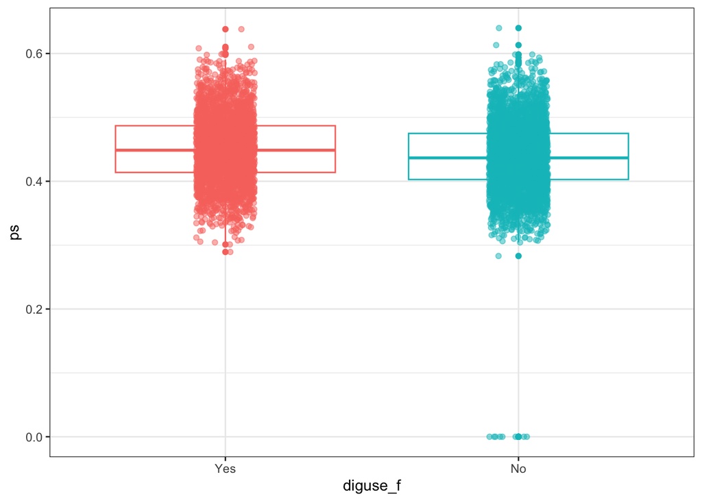

```r
ggplot(dig_i, aes(x = diguse_f, y = ps, color = diguse_f)) +
    geom_boxplot() +
    geom_jitter(width = 0.1, alpha = 0.5) +
    guides(color = "none")
```

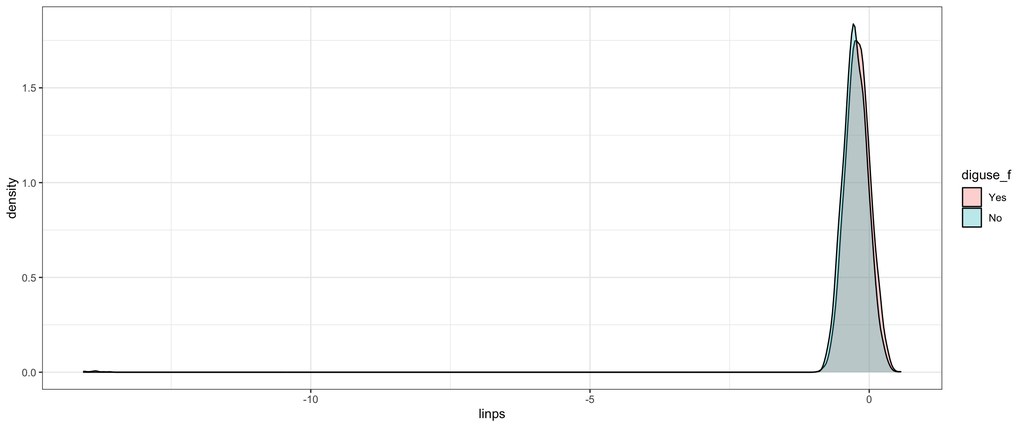

```r
ggplot(dig_i, aes(x = linps, fill = diguse_f)) +
    geom_density(alpha = 0.3)
```

We can see a fair amount of overlap across the two treatment groups. I will use Rubin’s Rules to help assess the amount of overlap at this point, before any adjustments for the propensity score.

## 3.4 Rubin’s Rules

### 3.4.1 Rubin’s Rule 1

First, the absolute value of the standardized difference of the linear propensity score, comparing the intervention group to the control group, should be close to 0, ideally below 10%, and in any case less than 50%.

```r
rubin1.unadj <- with(dig_i,
     abs(100*(mean(linps[diguse==1])-mean(linps[diguse==0]))/sd(linps)))
rubin1.unadj
```

```
[1] 14.63593
```

Rubin’s Rule 1 is barely satisfied.

### 3.4.2 Rubin’s Rule 2

Second, the ratio of the variance of the linear propensity score in the intervention group to the variance of the linear propensity score in the control group should be close to 1, ideally between 4/5 and 5/4, but certainly between 1/2 and 2.

```r
rubin2.unadj <- with(dig_i,
  var(linps[diguse == 1]) / var(linps[diguse == 0]))

rubin2.unadj
```

```
[1] 0.1078099
```

Rubin’s Rule 2 is not satisfied, further adjustment of the propensity score is needed to achieve better covariate balance. Therefore, a 1:1 greedy matching procedure will be performed.

## 3.5 1:1 Matching

### 3.5.1 Matching without Replacement

To match on the linear propensity score:

```r
X <- dig_i$linps
Tr <- as.logical(dig_i$diguse)
match1 <- Match(Tr=Tr, X=X, M = 1, replace=FALSE, ties=FALSE)
summary(match1)
```

```
Estimate...  0
SE.........  0
T-stat.....  NaN
p.val......  NA

Original number of observations..............  6800
Original number of treated obs...............  3017
Matched number of observations...............  3017
Matched number of observations  (unweighted).  3017
```

### 3.5.2 Assessing the Balance

Below I will assess the match balance from the 1:1 matching.

```r
set.seed(500)
mb1 <- MatchBalance(diguse ~ age + race + sex + bmi +
                    ejf_per + klevel + creat + sysbp + diabp +
                    heartrte + chfdur + diabetes + hyperten + prevmi +
                    angina + functcls + rales + elevjvp + pedema +
                    restdys + ps + linps,
                    data=dig_i, match.out = match1, nboots=500)
```

```
***** (V1) age *****
                       Before Matching       After Matching
mean treatment........      63.34             63.34
mean control..........     63.597            63.292
std mean diff.........    -2.3767           0.45104

mean raw eQQ diff.....    0.43619           0.39874
med  raw eQQ diff.....          0                 0
max  raw eQQ diff.....          4                 4

mean eCDF diff........  0.0059798         0.0054577
med  eCDF diff........  0.0026216         0.0039775
max  eCDF diff........   0.023256          0.016241

var ratio (Tr/Co).....    0.96254            0.9474
T-test p-value........    0.33439           0.86094
KS Bootstrap p-value..      0.244             0.688
KS Naive p-value......    0.32411           0.82107
KS Statistic..........   0.023256          0.016241


***** (V2) race *****
                       Before Matching       After Matching
mean treatment........     1.1561            1.1561
mean control..........     1.1375            1.1521
std mean diff.........     5.1397            1.0956

mean raw eQQ diff.....   0.018893         0.0039775
med  raw eQQ diff.....          0                 0
max  raw eQQ diff.....          1                 1

mean eCDF diff........  0.0093292         0.0019887
med  eCDF diff........  0.0093292         0.0019887
max  eCDF diff........   0.018658         0.0039775

var ratio (Tr/Co).....     1.1112            1.0213
T-test p-value........   0.031275            0.6574


***** (V3) sex *****
```

[output cut: 394 more lines]

```
med  eCDF diff........   0.066871        0.00099437
max  eCDF diff........   0.091833          0.024859

var ratio (Tr/Co).....    0.10781             1.078
T-test p-value........  5.066e-11        < 2.22e-16
KS Bootstrap p-value.. < 2.22e-16             0.288
KS Naive p-value...... 1.0152e-12           0.30883
KS Statistic..........   0.091833          0.024859


Before Matching Minimum p.value: < 2.22e-16
Variable Name(s): ejf_per ps linps  Number(s): 5 21 22

After Matching Minimum p.value: < 2.22e-16
Variable Name(s): ps linps  Number(s): 21 22
```

```r
covnames <- c("age", "race", "sex", "bmi",
              "ejf_per", "klevel", "creat", "sysbp", "diabp",
              "heartrte", "chfdur", "diabetes", "hyperten", "prevmi",
              "angina", "functcls", "rales", "elevjvp", "pedema",
              "restdys", "ps", "linps")

pre.szd <- NULL; post.szd <- NULL
for(i in 1:length(covnames)) {
pre.szd[i] <- mb1$BeforeMatching[[i]]$sdiff.pooled
post.szd[i] <- mb1$AfterMatching[[i]]$sdiff.pooled
}
```

```r
match_szd <- data.frame(covnames, pre.szd, post.szd)
print(match_szd, digits=3)
```

```
   covnames pre.szd post.szd
1       age  -2.354    0.451
2      race   5.273    1.096
3       sex   3.579    0.236
4       bmi   1.577   -0.645
5   ejf_per -16.221   -2.430
6    klevel  -6.576   -1.248
7     creat   2.392    0.338
8     sysbp  -0.385    0.217
9     diabp  -0.560   -0.852
10 heartrte  -1.691   -0.329
11   chfdur  -2.426   -0.614
12 diabetes  -5.906   -0.149
13 hyperten   1.347   -0.200
14   prevmi   1.743    0.627
15   angina  -4.708    1.518
16 functcls   6.856    0.758
17    rales   2.785    0.687
18  elevjvp   6.639    2.132
19   pedema  -1.311    0.343
20  restdys   1.216    0.649
21       ps  22.556    2.815
22    linps  15.325    2.772
```

Next, a Love Plot is used to describing standardized differences before and after matching

```r
b <- bal.tab(match1,
             diguse ~ age + race + sex + bmi + ejf_per + klevel +
                 creat + sysbp + diabp + heartrte + chfdur +
                 diabetes + hyperten + prevmi + angina + functcls +
                 rales + elevjvp + pedema + restdys + ps + linps,
             data=dig_i, stats = c("m", "v"), un = TRUE,
             quick = FALSE)
```

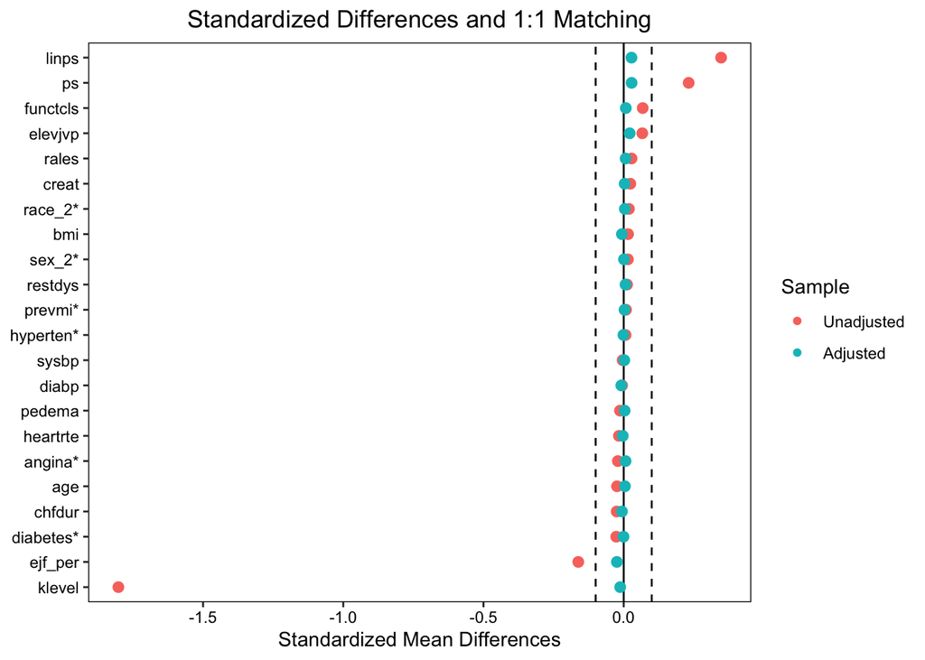

```r
p <- love.plot(b, threshold = .1, size = 3,
               var.order = "unadjusted", stars = "raw",
               title = "Standardized Differences and 1:1 Matching")
p
```

Variance ratios before and after matching are also illustrated.

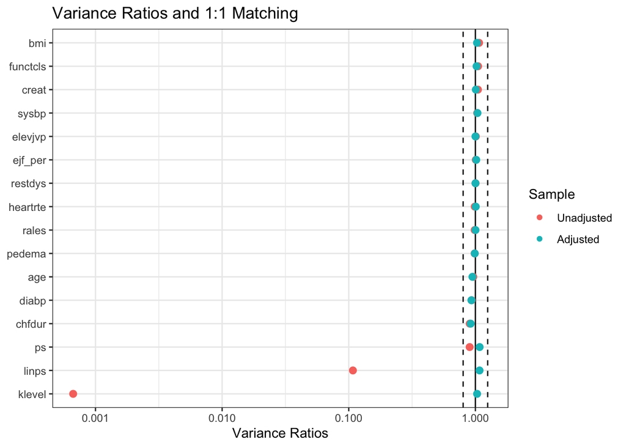

```r
p <- love.plot(b, stat = "v",
               threshold = 1.25, size = 3,
               var.order = "unadjusted",
               title = "Variance Ratios and 1:1 Matching")
p + theme_bw()
```

### 3.5.3 Rubin’s Rules 1 and 2 for Matching

Create a new data frame, containing only the matched sample.

```r
matches_1 <- factor(rep(match1$index.treated, 2))

dig.matches_1 <- cbind(matches_1,
          dig_i[c(match1$index.control, match1$index.treated),])
```

Rubin’s Rules 1:

```r
rubin1.m1 <- with(dig.matches_1,
      abs(100*(mean(linps[diguse==1])-mean(linps[diguse==0]))/sd(linps)))
rubin1.m1
```

```
[1] 2.823234
```

Rubin’s Rules 2:

```r
rubin2.m1 <- with(dig.matches_1,
                  var(linps[diguse == 1]) / var(linps[diguse == 0]))
rubin2.m1
```

```
[1] 1.078015
```

Rubin’s Rules 1 and 2 are both satisfied.

## 3.6 Causal Effect Estimate

```r
whf_adj_m1 <- clogit(whf ~ diguse + strata(matches_1), data = dig.matches_1)

summary(whf_adj_m1)
```

```
Call:
coxph(formula = Surv(rep(1, 6034L), whf) ~ diguse + strata(matches_1),
    data = dig.matches_1, method = "exact")

  n= 6034, number of events= 1931

          coef exp(coef) se(coef)     z Pr(>|z|)
diguse 0.49986   1.64848  0.05697 8.774   <2e-16 ***
---
Signif. codes:  0 '***' 0.001 '**' 0.01 '*' 0.05 '.' 0.1 ' ' 1

       exp(coef) exp(-coef) lower .95 upper .95
diguse     1.648     0.6066     1.474     1.843

Concordance= 0.622  (se = 0.019 )
Likelihood ratio test= 79.4  on 1 df,   p=<2e-16
Wald test            = 76.98  on 1 df,   p=<2e-16
Score (logrank) test = 78.6  on 1 df,   p=<2e-16
```

```r
tidy(whf_adj_m1, exponentiate = TRUE,
     conf.int = TRUE, conf.level = 0.95) |>
  gt() |> fmt_number(decimals = 3)
```

| term | estimate | std.error | statistic | p.value | conf.low | conf.high |
| --- | --- | --- | --- | --- | --- | --- |
| diguse | 1.648 | 0.057 | 8.774 | 0.000 | 1.474 | 1.843 |

After 1:1 propensity score matching, patients who used Digoxin within one week prior to randomization had 1.648 times the odds of having worsening heart failure compared to those not used, with a 95% CI ranging from 1.474 to 1.843, suggesting that there are meaningful difference between two groups.

## 3.7 Sensitivity Analyses After Matching

A Rosenbaum sensitivity analysis was conducted to assess the robustness of the estimated treatment effect to potential unmeasured confounding.

```r
pair_data <- dig.matches_1 |>
  group_by(matches_1) |>
  summarise(y_treat = whf[diguse == 1],
            y_ctrl  = whf[diguse == 0],
            .groups = "drop")

out.tab <- table(
  No_diguseazine = pair_data$y_ctrl,
  diguseazine = pair_data$y_treat)

out.tab
```

```
              diguseazine
No_diguseazine    0    1
             0 1396  816
             1  495  310
```

```r
binarysens(x = out.tab["1", "0"], y = out.tab["0", "1"],
           Gamma = 2, GammaInc = 0.05)
```

```
 Rosenbaum Sensitivity Test

Unconfounded estimate ....  0

 Gamma Lower bound Upper bound
  1.00           0     0.00000
  1.05           0     0.00000
  1.10           0     0.00000
  1.15           0     0.00000
  1.20           0     0.00000
  1.25           0     0.00000
  1.30           0     0.00001
  1.35           0     0.00019
  1.40           0     0.00179
  1.45           0     0.01103
  1.50           0     0.04558
  1.55           0     0.13345
  1.60           0     0.29086
  1.65           0     0.49600
  1.70           0     0.69615
  1.75           0     0.84621
  1.80           0     0.93470
  1.85           0     0.97662
  1.90           0     0.99288
  1.95           0     0.99814
  2.00           0     0.99958

 Note: Gamma is Odds of Differential Assignment To
 Treatment Due to Unobserved Factors
```

# 4 Task 4. Propensity Weighting Analysis.

## 4.1 Propensity Score Weighting (ATT approach)

```r
dig_df <- data.frame(dig_i)
```

```r
ps_dig <- ps(diguse ~ age + race + sex + bmi + ejf_per + klevel +
                 creat + sysbp + diabp + heartrte + chfdur +
                 diabetes + hyperten + prevmi + angina + functcls +
                 rales + elevjvp + pedema + restdys,
             data = dig_df,
             n.trees = 5000,
             interaction.depth = 2,
             stop.method = c("es.mean"),
             estimand = "ATT",
             verbose = FALSE)
```

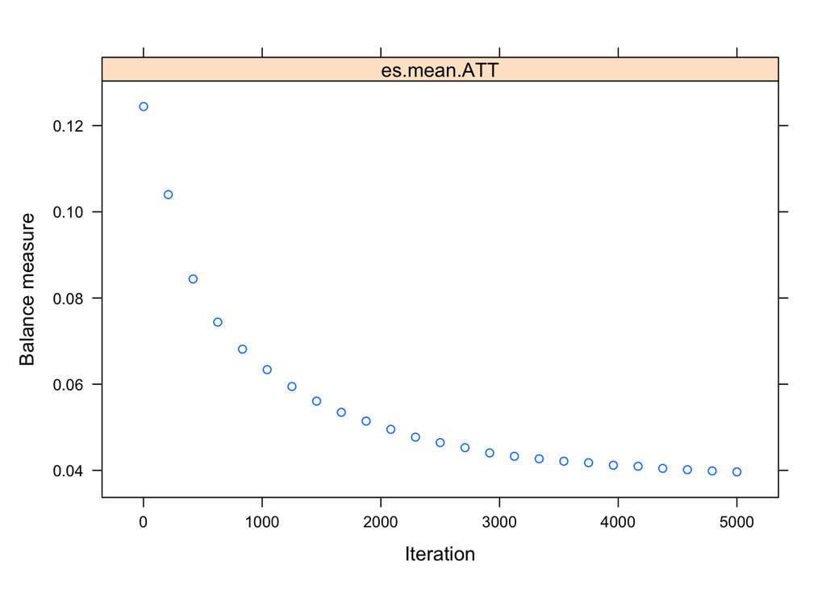

```r
plot(ps_dig)
```

We can see that the simulation has run long enough to stabilize estimates.

## 4.2 Assessing Balance

```r
b2 <- bal.tab(ps_dig, full.stop.method = "es.mean.att",
        stats = c("m", "v"), un = TRUE)

b2
```

```
Balance Measures
               Type Diff.Un V.Ratio.Un Diff.Adj V.Ratio.Adj
prop.score Distance  0.6965     1.1618   0.4275      1.2898
age         Contin. -0.0238     0.9625  -0.0106      1.0202
race_2       Binary  0.0187          .   0.0083           .
sex_2        Binary  0.0149          .   0.0087           .
bmi         Contin.  0.0155     1.0695   0.0096      1.0980
ejf_per     Contin. -0.1619     1.0072  -0.0143      1.0078
klevel      Contin. -1.8020     0.0007  -0.5671      0.0021
creat       Contin.  0.0236     1.0474   0.0134      1.0456
sysbp       Contin. -0.0038     1.0329   0.0081      1.0504
diabp       Contin. -0.0057     0.9337   0.0007      1.0128
heartrte    Contin. -0.0170     0.9878   0.0001      1.0457
chfdur      Contin. -0.0249     0.9016   0.0128      1.0355
diabetes     Binary -0.0266          .  -0.0062           .
hyperten     Binary  0.0067          .   0.0065           .
prevmi       Binary  0.0083          .   0.0062           .
angina       Binary -0.0208          .  -0.0050           .
functcls    Contin.  0.0677     1.0503   0.0190      1.0237
rales       Contin.  0.0279     0.9866   0.0084      1.0043
elevjvp     Contin.  0.0663     1.0080   0.0184      1.0047
pedema      Contin. -0.0132     0.9860  -0.0127      0.9897
restdys     Contin.  0.0122     1.0027  -0.0025      1.0140

Effective sample sizes
           Control Treated
Unadjusted 3783.      3017
Adjusted   3474.54    3017
```

## 4.3 Rubin’s Rules After Weighting

### 4.3.1 Rubin’s Rule 1.

```r
100*b2[1]$Balance$Diff.Un[1] # imbalance prior to weighting
```

```
[1] 69.6529
```

```r
100*b2[1]$Balance$Diff.Adj[1] # imbalance after weighting
```

```
[1] 42.74692
```

This is still indicative of some difficulty reaching a completely reasonable level of balance, but improved.

### 4.3.2 Rubin’s Rule 2.

```r
b2[1]$Balance$V.Ratio.Un[1] # imbalance prior to weighting
```

```
[1] 1.161813
```

```r
b2[1]$Balance$V.Ratio.Adj[1] # imbalance after weighting
```

```
[1] 1.289799
```

There is no particular problem with Rule 2.

## 4.4 Love plots

### 4.4.1 Standardized Differences

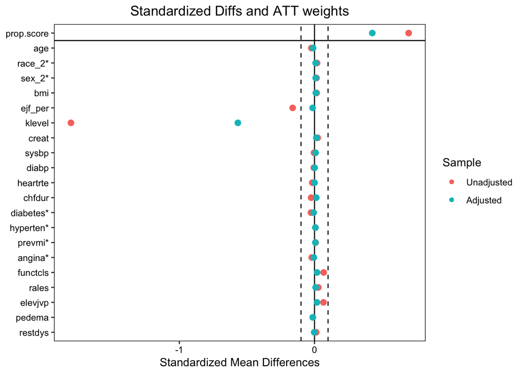

```r
p <- love.plot(b2, threshold = .1, size = 3, stars = "raw",
               title = "Standardized Diffs and ATT weights")
p
```

### 4.4.2 Variance Ratios

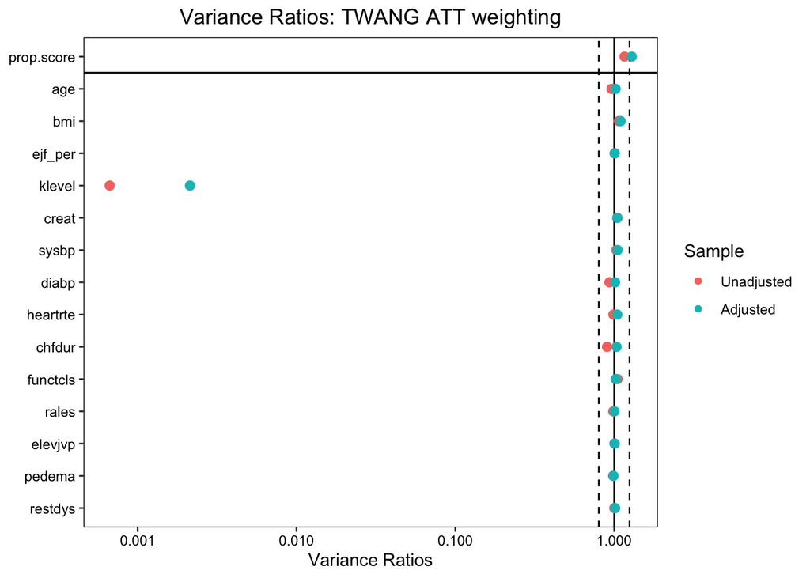

```r
p <- love.plot(b2, stat = "v",
               threshold = 1.25, size = 3,
               title = "Variance Ratios: TWANG ATT weighting")
p
```

## 4.5 Propensity-weighted Estimate for the Outcome `whf`

```r
digwts_design <- svydesign(
    ids=~1, weights=~get.weights(ps_dig, stop.method = "es.mean"),
    data=dig_df) # using twang ATT weights

adj_whf_wtd <- svyglm(whf ~ diguse, design = digwts_design,
                      family=quasibinomial())

wt_twangatt_res_whf <-
    tidy(adj_whf_wtd, exponentiate = TRUE,
         conf.int = TRUE, conf.level = 0.95) |>
    select(term, estimate, std.error,
           lo95 = conf.low, hi95 = conf.high)

wt_twangatt_res_whf |> gt() |>
  fmt_number(decimals = 3)
```

| term | estimate | std.error | lo95 | hi95 |
| --- | --- | --- | --- | --- |
| (Intercept) | 0.365 | 0.039 | 0.338 | 0.394 |
| diguse | 1.630 | 0.054 | 1.466 | 1.813 |

After ATT propensity weighting, patients who used Digoxin within one week prior to randomization had 1.630 times the odds of having worsening heart failure compared to those not used, with a 95% CI ranging from 1.466 to 1.813.

# 5 Task 5. Discusion.

A table of all of the results I have obtained is built here.

| Method | Est. Causal Effect | Est. 95% CI |
| --- | --- | --- |
| No covariate adjustment | 1.741 | (1.570 - 1.932) |
| 1:1 matching | 1.648 | (1.474 - 1.843) |
| PS weighting | 1.630 | (1.466 - 1.813) |

The estimated effects were highly consistent across the three analytic approaches. The unadjusted analysis yielded an effect estimate of 1.741 (95% CI: 1.570, 1.932), while the 1:1 matched analysis and propensity score–weighted analysis produced estimates of 1.648 (95% CI: 1.474, 1.843) and 1.630 (95% CI: 1.466, 1.813), respectively. The close agreement in both point estimates and confidence intervals suggests that the choice of method had limited impact on the estimated effect in this study.

The crude analysis suggested a strong association between Digoxin use and the outcome. After adjustment using propensity score methods, the estimated effect was weakened, indicating that part of the crude association was likely due to confounding.

Notably, the estimates obtained from matching and weighting were very similar, suggesting that the results are relatively robust to the choice of propensity score method. However, examination of covariate balance after adjustment reveals some limitations of the propensity score weighting approach. In particular, the adjusted standardized difference for potassium level (klevel), which exhibited the largest imbalance prior to adjustment, remained relatively elevated after weighting. This suggests that the weighting model did not fully achieve balance for this covariate, indicating potential residual imbalance despite the overall similarity in effect estimates.

Patients who used Digoxin prior to randomization had a higher risk of worsening heart failure during follow-up. However, this likely reflects confounding by indication, as patients receiving Digoxin before the trial were likely to have more severe underlying disease. Despite adjustment using propensity score methods, residual confounding may still remain. Digoxin use prior to randomization may serve as a marker of disease severity rather than a causal risk factor.

# 6 Use of AI

AI supported this project by assisting with R code development and helping refine sentence grammar.